# Upstrap Calibration Simulation: Tables & Visualizations

# Heatmap Figures: 5% Type I Error (Null Scenarios)

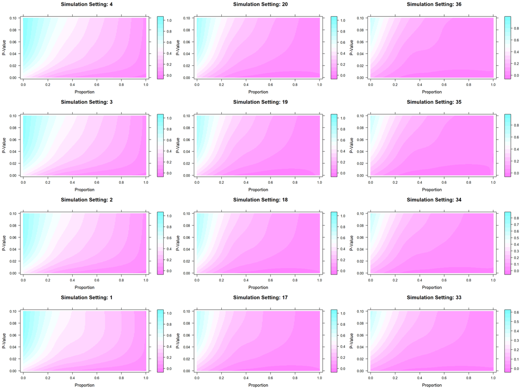

```r
#grid figures: 5% type I error (null scenario)
grid.arrange(plot_S4,plot_S20,plot_S36,
             plot_S3,plot_S19,plot_S35,
             plot_S2,plot_S18,plot_S34,
             plot_S1,plot_S17,plot_S33,
             ncol=3)
```

# Heatmap Figures: 50% Power (Alternative Scenarios)

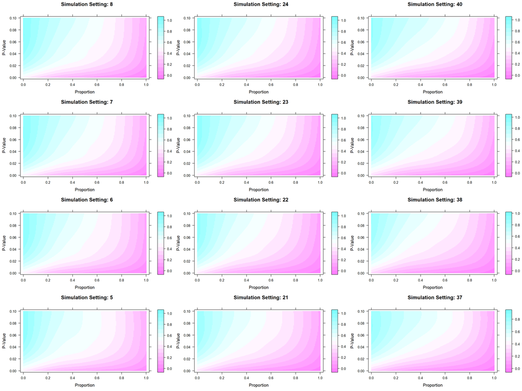

```r
#grid figures: 50% power (alternative scenario)
grid.arrange(plot_S8,plot_S24,plot_S40,
             plot_S7,plot_S23,plot_S39,
             plot_S6,plot_S22,plot_S38,
             plot_S5,plot_S21,plot_S37,
             ncol=3)
```

# Heatmap Figures: 80% Power (Alternative Scenarios)

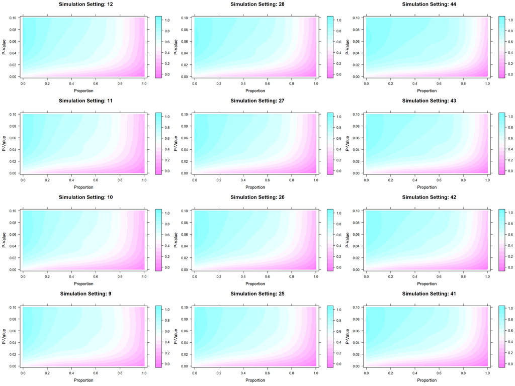

```r
#grid figures: 80% power (alternative scenario)
grid.arrange(plot_S12,plot_S28,plot_S44,
             plot_S11,plot_S27,plot_S43,
             plot_S10,plot_S26,plot_S42,
             plot_S9,plot_S25,plot_S41,
             ncol=3)
```

# Heatmap Figures: 95% Power (Alternative Scenarios)

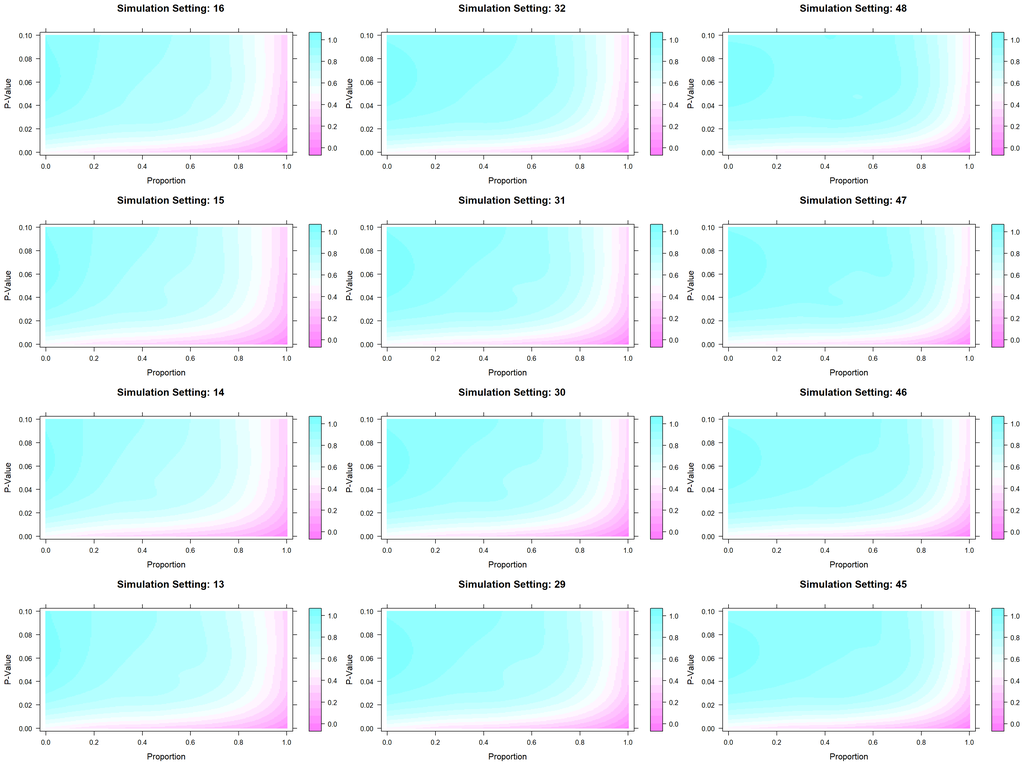

```r
#grid figures: 95% power (alternative scenario)
grid.arrange(plot_S16,plot_S32,plot_S48,
             plot_S15,plot_S31,plot_S47,
             plot_S14,plot_S30,plot_S46,
             plot_S13,plot_S29,plot_S45,
             ncol=3)
```

# Arbitrary Calibration Table (rough draft)

For arbitrarily selected P = 0.05 and Proportion = 0.05, 0.10, 0.80, or 0.95, the resulting power and type I error rate is shown (done separately for each sample size, interim fraction, and power setting (50%, 80%, 95%)).

```r
dat_calibrate_arbitrary %>%
  rename(`Interim Fraction`=interim_fraction) %>%
  kbl(caption = "Arbitrary Calibration Results") %>%
  kable_classic(full_width = F, html_font = "Cambria")
```

Arbitrary Calibration Results

|  | P | Proportion | n | Interim Fraction | AlternativeRejectionRate0.5 | AlternativeRejectionRate0.8 | AlternativeRejectionRate0.95 | NullRejectionRate0.05 |
| --- | --- | --- | --- | --- | --- | --- | --- | --- |
| 2533 | 0.05 | 0.05 | 40 | 0.25 | 0.843 | 0.905 | 0.959 | 0.753 |
| 2534 | 0.05 | 0.05 | 40 | 0.50 | 0.743 | 0.905 | 0.976 | 0.423 |
| 2535 | 0.05 | 0.05 | 40 | 0.75 | 0.688 | 0.896 | 0.974 | 0.214 |
| 2536 | 0.05 | 0.05 | 160 | 0.25 | 0.807 | 0.866 | 0.926 | 0.663 |
| 2537 | 0.05 | 0.05 | 160 | 0.50 | 0.772 | 0.898 | 0.963 | 0.499 |
| 2538 | 0.05 | 0.05 | 160 | 0.75 | 0.681 | 0.881 | 0.974 | 0.253 |
| 2539 | 0.05 | 0.05 | 600 | 0.25 | 0.877 | 0.907 | 0.960 | 0.774 |
| 2540 | 0.05 | 0.05 | 600 | 0.50 | 0.828 | 0.901 | 0.981 | 0.515 |
| 2541 | 0.05 | 0.05 | 600 | 0.75 | 0.756 | 0.919 | 0.986 | 0.295 |
| 2542 | 0.05 | 0.05 | 2000 | 0.25 | 0.865 | 0.922 | 0.961 | 0.786 |
| 2543 | 0.05 | 0.05 | 2000 | 0.50 | 0.822 | 0.927 | 0.983 | 0.552 |
| 2544 | 0.05 | 0.05 | 2000 | 0.75 | 0.777 | 0.932 | 0.990 | 0.287 |
| 2545 | 0.05 | 0.10 | 40 | 0.25 | 0.737 | 0.847 | 0.944 | 0.627 |
| 2546 | 0.05 | 0.10 | 40 | 0.50 | 0.650 | 0.836 | 0.957 | 0.294 |
| 2547 | 0.05 | 0.10 | 40 | 0.75 | 0.591 | 0.839 | 0.958 | 0.140 |
| 2548 | 0.05 | 0.10 | 160 | 0.25 | 0.782 | 0.848 | 0.912 | 0.617 |
| 2549 | 0.05 | 0.10 | 160 | 0.50 | 0.720 | 0.883 | 0.956 | 0.417 |
| 2550 | 0.05 | 0.10 | 160 | 0.75 | 0.608 | 0.850 | 0.955 | 0.203 |
| 2551 | 0.05 | 0.10 | 600 | 0.25 | 0.811 | 0.854 | 0.935 | 0.659 |
| 2552 | 0.05 | 0.10 | 600 | 0.50 | 0.775 | 0.879 | 0.968 | 0.416 |
| 2553 | 0.05 | 0.10 | 600 | 0.75 | 0.706 | 0.885 | 0.980 | 0.233 |
| 2554 | 0.05 | 0.10 | 2000 | 0.25 | 0.791 | 0.870 | 0.929 | 0.658 |
| 2555 | 0.05 | 0.10 | 2000 | 0.50 | 0.756 | 0.892 | 0.968 | 0.433 |
| 2556 | 0.05 | 0.10 | 2000 | 0.75 | 0.714 | 0.906 | 0.985 | 0.225 |
| 2713 | 0.05 | 0.80 | 40 | 0.25 | 0.349 | 0.502 | 0.679 | 0.179 |
| 2714 | 0.05 | 0.80 | 40 | 0.50 | 0.301 | 0.503 | 0.734 | 0.052 |
| 2715 | 0.05 | 0.80 | 40 | 0.75 | 0.268 | 0.538 | 0.817 | 0.027 |
| 2716 | 0.05 | 0.80 | 160 | 0.25 | 0.334 | 0.491 | 0.639 | 0.153 |
| 2717 | 0.05 | 0.80 | 160 | 0.50 | 0.301 | 0.527 | 0.739 | 0.058 |
| 2718 | 0.05 | 0.80 | 160 | 0.75 | 0.277 | 0.557 | 0.787 | 0.035 |
| 2719 | 0.05 | 0.80 | 600 | 0.25 | 0.362 | 0.491 | 0.655 | 0.162 |
| 2720 | 0.05 | 0.80 | 600 | 0.50 | 0.331 | 0.551 | 0.759 | 0.049 |
| 2721 | 0.05 | 0.80 | 600 | 0.75 | 0.361 | 0.629 | 0.846 | 0.025 |
| 2722 | 0.05 | 0.80 | 2000 | 0.25 | 0.361 | 0.528 | 0.688 | 0.174 |
| 2723 | 0.05 | 0.80 | 2000 | 0.50 | 0.340 | 0.556 | 0.775 | 0.060 |
| 2724 | 0.05 | 0.80 | 2000 | 0.75 | 0.362 | 0.659 | 0.863 | 0.032 |
| 2749 | 0.05 | 0.95 | 40 | 0.25 | 0.343 | 0.492 | 0.666 | 0.173 |
| 2750 | 0.05 | 0.95 | 40 | 0.50 | 0.183 | 0.353 | 0.621 | 0.020 |
| 2751 | 0.05 | 0.95 | 40 | 0.75 | 0.163 | 0.384 | 0.664 | 0.010 |
| 2752 | 0.05 | 0.95 | 160 | 0.25 | 0.229 | 0.372 | 0.541 | 0.089 |
| 2753 | 0.05 | 0.95 | 160 | 0.50 | 0.168 | 0.348 | 0.577 | 0.028 |
| 2754 | 0.05 | 0.95 | 160 | 0.75 | 0.187 | 0.438 | 0.695 | 0.018 |
| 2755 | 0.05 | 0.95 | 600 | 0.25 | 0.242 | 0.361 | 0.530 | 0.093 |
| 2756 | 0.05 | 0.95 | 600 | 0.50 | 0.195 | 0.393 | 0.615 | 0.020 |
| 2757 | 0.05 | 0.95 | 600 | 0.75 | 0.234 | 0.492 | 0.739 | 0.007 |
| 2758 | 0.05 | 0.95 | 2000 | 0.25 | 0.240 | 0.379 | 0.547 | 0.090 |
| 2759 | 0.05 | 0.95 | 2000 | 0.50 | 0.204 | 0.408 | 0.625 | 0.015 |
| 2760 | 0.05 | 0.95 | 2000 | 0.75 | 0.226 | 0.514 | 0.778 | 0.013 |

# Strictly Fixed P-Value Calibration Table (rough draft)

For fixed P = 0.05, the proportion producing maximum power (with type I error rate <= 0.05) was selected (done separately for each sample size, interim fraction, and power setting (50%, 80%, 95%)).

```r
dat_calibrate_pfixedstrict %>%
  rename(`Interim Fraction`=interim_fraction) %>%
  kbl(caption = "Strictly Fixed P-Value Calibration Results") %>%
  kable_classic(full_width = F, html_font = "Cambria")
```

Strictly Fixed P-Value Calibration Results

| P | Proportion | n | Interim Fraction | AlternativeRejectionRate0.5 | AlternativeRejectionRate0.8 | AlternativeRejectionRate0.95 | NullRejectionRate0.05 | MaxPower0.5 | MaxPower0.8 | MaxPower0.95 |
| --- | --- | --- | --- | --- | --- | --- | --- | --- | --- | --- |
| 0.05 | 1.00 | 40 | 0.25 | 0.000 | 0.000 | 0.000 | 0.000 | Yes | Yes | Yes |
| 0.05 | 0.85 | 40 | 0.50 | 0.291 | 0.486 | 0.709 | 0.036 | Yes | Yes | Yes |
| 0.05 | 0.65 | 40 | 0.75 | 0.358 | 0.622 | 0.865 | 0.048 | Yes | Yes | Yes |
| 0.05 | 1.00 | 160 | 0.25 | 0.000 | 0.000 | 0.000 | 0.000 | Yes | Yes | Yes |
| 0.05 | 0.85 | 160 | 0.50 | 0.267 | 0.488 | 0.700 | 0.047 | Yes | Yes | Yes |
| 0.05 | 0.65 | 160 | 0.75 | 0.358 | 0.636 | 0.853 | 0.049 | Yes | Yes | Yes |
| 0.05 | 1.00 | 600 | 0.25 | 0.000 | 0.000 | 0.000 | 0.000 | Yes | Yes | Yes |
| 0.05 | 0.80 | 600 | 0.50 | 0.331 | 0.551 | 0.759 | 0.049 | Yes | Yes | Yes |
| 0.05 | 0.60 | 600 | 0.75 | 0.452 | 0.706 | 0.896 | 0.047 | Yes | Yes | Yes |
| 0.05 | 1.00 | 2000 | 0.25 | 0.000 | 0.000 | 0.000 | 0.000 | Yes | Yes | Yes |
| 0.05 | 0.85 | 2000 | 0.50 | 0.308 | 0.525 | 0.742 | 0.046 | Yes | Yes | Yes |
| 0.05 | 0.65 | 2000 | 0.75 | 0.443 | 0.729 | 0.903 | 0.045 | Yes | Yes | Yes |

# Fixed P-Value Calibration Table (rough draft)

For fixed P <= 0.05, the proportion producing maximum power (with type I error rate <= 0.05) was selected (done separately for each sample size, interim fraction, and power setting (50%, 80%, 95%)).

```r
dat_calibrate_pfixed %>%
  rename(`Interim Fraction`=interim_fraction) %>%
  kbl(caption = "Fixed P-Value Calibration Results") %>%
  kable_classic(full_width = F, html_font = "Cambria")
```

Fixed P-Value Calibration Results

| P | Proportion | n | Interim Fraction | AlternativeRejectionRate0.5 | AlternativeRejectionRate0.8 | AlternativeRejectionRate0.95 | NullRejectionRate0.05 | MaxPower0.5 | MaxPower0.8 | MaxPower0.95 |
| --- | --- | --- | --- | --- | --- | --- | --- | --- | --- | --- |
| 0.000 | 0.00 | 40 | 0.25 | 0.000 | 0.000 | 0.000 | 0.000 | Yes | Yes | Yes |
| 0.000 | 0.05 | 40 | 0.25 | 0.000 | 0.000 | 0.000 | 0.000 | Yes | Yes | Yes |
| 0.000 | 0.10 | 40 | 0.25 | 0.000 | 0.000 | 0.000 | 0.000 | Yes | Yes | Yes |
| 0.000 | 0.15 | 40 | 0.25 | 0.000 | 0.000 | 0.000 | 0.000 | Yes | Yes | Yes |
| 0.000 | 0.20 | 40 | 0.25 | 0.000 | 0.000 | 0.000 | 0.000 | Yes | Yes | Yes |
| 0.000 | 0.25 | 40 | 0.25 | 0.000 | 0.000 | 0.000 | 0.000 | Yes | Yes | Yes |
| 0.000 | 0.30 | 40 | 0.25 | 0.000 | 0.000 | 0.000 | 0.000 | Yes | Yes | Yes |
| 0.000 | 0.35 | 40 | 0.25 | 0.000 | 0.000 | 0.000 | 0.000 | Yes | Yes | Yes |
| 0.000 | 0.40 | 40 | 0.25 | 0.000 | 0.000 | 0.000 | 0.000 | Yes | Yes | Yes |
| 0.000 | 0.45 | 40 | 0.25 | 0.000 | 0.000 | 0.000 | 0.000 | Yes | Yes | Yes |
| 0.000 | 0.50 | 40 | 0.25 | 0.000 | 0.000 | 0.000 | 0.000 | Yes | Yes | Yes |
| 0.000 | 0.55 | 40 | 0.25 | 0.000 | 0.000 | 0.000 | 0.000 | Yes | Yes | Yes |
| 0.000 | 0.60 | 40 | 0.25 | 0.000 | 0.000 | 0.000 | 0.000 | Yes | Yes | Yes |
| 0.000 | 0.65 | 40 | 0.25 | 0.000 | 0.000 | 0.000 | 0.000 | Yes | Yes | Yes |
| 0.000 | 0.70 | 40 | 0.25 | 0.000 | 0.000 | 0.000 | 0.000 | Yes | Yes | Yes |
| 0.000 | 0.75 | 40 | 0.25 | 0.000 | 0.000 | 0.000 | 0.000 | Yes | Yes | Yes |
| 0.000 | 0.80 | 40 | 0.25 | 0.000 | 0.000 | 0.000 | 0.000 | Yes | Yes | Yes |
| 0.000 | 0.85 | 40 | 0.25 | 0.000 | 0.000 | 0.000 | 0.000 | Yes | Yes | Yes |
| 0.000 | 0.90 | 40 | 0.25 | 0.000 | 0.000 | 0.000 | 0.000 | Yes | Yes | Yes |
| 0.000 | 0.95 | 40 | 0.25 | 0.000 | 0.000 | 0.000 | 0.000 | Yes | Yes | Yes |
| 0.000 | 1.00 | 40 | 0.25 | 0.000 | 0.000 | 0.000 | 0.000 | Yes | Yes | Yes |
| 0.005 | 1.00 | 40 | 0.25 | 0.000 | 0.000 | 0.000 | 0.000 | Yes | Yes | Yes |
| 0.010 | 1.00 | 40 | 0.25 | 0.000 | 0.000 | 0.000 | 0.000 | Yes | Yes | Yes |
| 0.015 | 1.00 | 40 | 0.25 | 0.000 | 0.000 | 0.000 | 0.000 | Yes | Yes | Yes |
| 0.020 | 1.00 | 40 | 0.25 | 0.000 | 0.000 | 0.000 | 0.000 | Yes | Yes | Yes |
| 0.025 | 1.00 | 40 | 0.25 | 0.000 | 0.000 | 0.000 | 0.000 | Yes | Yes | Yes |
| 0.030 | 1.00 | 40 | 0.25 | 0.000 | 0.000 | 0.000 | 0.000 | Yes | Yes | Yes |
| 0.035 | 1.00 | 40 | 0.25 | 0.000 | 0.000 | 0.000 | 0.000 | Yes | Yes | Yes |
| 0.040 | 1.00 | 40 | 0.25 | 0.000 | 0.000 | 0.000 | 0.000 | Yes | Yes | Yes |
| 0.045 | 1.00 | 40 | 0.25 | 0.000 | 0.000 | 0.000 | 0.000 | Yes | Yes | Yes |
| 0.050 | 1.00 | 40 | 0.25 | 0.000 | 0.000 | 0.000 | 0.000 | Yes | Yes | Yes |
| 0.005 | 0.30 | 40 | 0.50 | 0.297 | 0.502 | 0.722 | 0.044 | Yes | No | No |
| 0.010 | 0.40 | 40 | 0.50 | 0.297 | 0.506 | 0.726 | 0.044 | Yes | Yes | Yes |
| 0.025 | 0.40 | 40 | 0.75 | 0.382 | 0.643 | 0.870 | 0.048 | No | No | Yes |
| 0.005 | 0.05 | 40 | 0.75 | 0.396 | 0.652 | 0.865 | 0.050 | Yes | No | No |
| 0.015 | 0.25 | 40 | 0.75 | 0.396 | 0.643 | 0.843 | 0.046 | Yes | No | No |
| 0.030 | 0.50 | 40 | 0.75 | 0.396 | 0.650 | 0.855 | 0.048 | Yes | No | No |
| 0.030 | 0.55 | 40 | 0.75 | 0.396 | 0.642 | 0.842 | 0.045 | Yes | No | No |
| 0.035 | 0.55 | 40 | 0.75 | 0.396 | 0.649 | 0.856 | 0.048 | Yes | No | No |
| 0.040 | 0.55 | 40 | 0.75 | 0.396 | 0.649 | 0.856 | 0.048 | Yes | No | No |
| 0.015 | 0.20 | 40 | 0.75 | 0.396 | 0.653 | 0.865 | 0.050 | Yes | Yes | No |
| 0.030 | 0.45 | 40 | 0.75 | 0.396 | 0.653 | 0.866 | 0.050 | Yes | Yes | No |
| 0.005 | 0.95 | 160 | 0.25 | 0.150 | 0.260 | 0.396 | 0.048 | Yes | Yes | Yes |
| 0.050 | 0.85 | 160 | 0.50 | 0.267 | 0.488 | 0.700 | 0.047 | Yes | Yes | Yes |
| 0.040 | 0.65 | 160 | 0.75 | 0.358 | 0.634 | 0.848 | 0.047 | Yes | No | No |
| 0.045 | 0.65 | 160 | 0.75 | 0.358 | 0.634 | 0.850 | 0.047 | Yes | No | No |
| 0.050 | 0.65 | 160 | 0.75 | 0.358 | 0.636 | 0.853 | 0.049 | Yes | Yes | Yes |
| 0.010 | 0.95 | 600 | 0.25 | 0.159 | 0.259 | 0.387 | 0.048 | Yes | Yes | Yes |
| 0.050 | 0.80 | 600 | 0.50 | 0.331 | 0.551 | 0.759 | 0.049 | Yes | Yes | Yes |
| 0.045 | 0.55 | 600 | 0.75 | 0.449 | 0.706 | 0.897 | 0.050 | No | No | Yes |
| 0.035 | 0.45 | 600 | 0.75 | 0.453 | 0.709 | 0.897 | 0.049 | Yes | Yes | Yes |
| 0.010 | 0.95 | 2000 | 0.25 | 0.143 | 0.260 | 0.426 | 0.047 | Yes | Yes | Yes |
| 0.015 | 0.60 | 2000 | 0.50 | 0.321 | 0.545 | 0.765 | 0.050 | Yes | No | No |
| 0.025 | 0.70 | 2000 | 0.50 | 0.321 | 0.547 | 0.766 | 0.050 | Yes | Yes | Yes |
| 0.025 | 0.40 | 2000 | 0.75 | 0.461 | 0.744 | 0.910 | 0.048 | No | No | Yes |
| 0.030 | 0.45 | 2000 | 0.75 | 0.459 | 0.744 | 0.910 | 0.050 | No | No | Yes |
| 0.035 | 0.50 | 2000 | 0.75 | 0.462 | 0.746 | 0.909 | 0.048 | Yes | Yes | No |

# Strictly Fixed Proportion Calibration Table (rough draft)

For fixed Proportion = 0.05, 0.10, 0.80, 0.95 the p-value producing maximum power (with type I error rate <= 0.05) was selected (done separately for each sample size, interim fraction, and power setting (50%, 80%, 95%)).

```r
dat_calibrate_propfixedstrict %>%
  rename(`Interim Fraction`=interim_fraction) %>%
  kbl(caption = "Strictly Fixed Proportion Calibration Results") %>%
  kable_classic(full_width = F, html_font = "Cambria")
```

Strictly Fixed Proportion Calibration Results

| P | Proportion | n | Interim Fraction | AlternativeRejectionRate0.5 | AlternativeRejectionRate0.8 | AlternativeRejectionRate0.95 | NullRejectionRate0.05 | MaxPower0.5 | MaxPower0.8 | MaxPower0.95 |
| --- | --- | --- | --- | --- | --- | --- | --- | --- | --- | --- |
| 0.000 | 0.05 | 40 | 0.25 | 0.000 | 0.000 | 0.000 | 0.000 | Yes | Yes | Yes |
| 0.000 | 0.05 | 40 | 0.50 | 0.000 | 0.000 | 0.000 | 0.000 | Yes | Yes | Yes |
| 0.005 | 0.05 | 40 | 0.75 | 0.396 | 0.652 | 0.865 | 0.050 | Yes | Yes | Yes |
| 0.000 | 0.05 | 160 | 0.25 | 0.000 | 0.000 | 0.000 | 0.000 | Yes | Yes | Yes |
| 0.000 | 0.05 | 160 | 0.50 | 0.000 | 0.000 | 0.000 | 0.000 | Yes | Yes | Yes |
| 0.000 | 0.05 | 160 | 0.75 | 0.000 | 0.000 | 0.000 | 0.000 | Yes | Yes | Yes |
| 0.000 | 0.05 | 600 | 0.25 | 0.000 | 0.000 | 0.000 | 0.000 | Yes | Yes | Yes |
| 0.000 | 0.05 | 600 | 0.50 | 0.000 | 0.000 | 0.000 | 0.000 | Yes | Yes | Yes |
| 0.000 | 0.05 | 600 | 0.75 | 0.000 | 0.000 | 0.000 | 0.000 | Yes | Yes | Yes |
| 0.000 | 0.05 | 2000 | 0.25 | 0.000 | 0.000 | 0.000 | 0.000 | Yes | Yes | Yes |
| 0.000 | 0.05 | 2000 | 0.50 | 0.000 | 0.000 | 0.000 | 0.000 | Yes | Yes | Yes |
| 0.000 | 0.05 | 2000 | 0.75 | 0.000 | 0.000 | 0.000 | 0.000 | Yes | Yes | Yes |
| 0.000 | 0.10 | 40 | 0.25 | 0.000 | 0.000 | 0.000 | 0.000 | Yes | Yes | Yes |
| 0.000 | 0.10 | 40 | 0.50 | 0.000 | 0.000 | 0.000 | 0.000 | Yes | Yes | Yes |
| 0.005 | 0.10 | 40 | 0.75 | 0.395 | 0.638 | 0.840 | 0.045 | Yes | Yes | Yes |
| 0.000 | 0.10 | 160 | 0.25 | 0.000 | 0.000 | 0.000 | 0.000 | Yes | Yes | Yes |
| 0.000 | 0.10 | 160 | 0.50 | 0.000 | 0.000 | 0.000 | 0.000 | Yes | Yes | Yes |
| 0.000 | 0.10 | 160 | 0.75 | 0.000 | 0.000 | 0.000 | 0.000 | Yes | Yes | Yes |
| 0.000 | 0.10 | 600 | 0.25 | 0.000 | 0.000 | 0.000 | 0.000 | Yes | Yes | Yes |
| 0.000 | 0.10 | 600 | 0.50 | 0.000 | 0.000 | 0.000 | 0.000 | Yes | Yes | Yes |
| 0.005 | 0.10 | 600 | 0.75 | 0.420 | 0.668 | 0.876 | 0.035 | Yes | Yes | Yes |
| 0.000 | 0.10 | 2000 | 0.25 | 0.000 | 0.000 | 0.000 | 0.000 | Yes | Yes | Yes |
| 0.000 | 0.10 | 2000 | 0.50 | 0.000 | 0.000 | 0.000 | 0.000 | Yes | Yes | Yes |
| 0.005 | 0.10 | 2000 | 0.75 | 0.431 | 0.724 | 0.898 | 0.044 | Yes | Yes | Yes |
| 0.000 | 0.80 | 40 | 0.25 | 0.000 | 0.000 | 0.000 | 0.000 | Yes | Yes | Yes |
| 0.035 | 0.80 | 40 | 0.50 | 0.288 | 0.482 | 0.697 | 0.035 | Yes | Yes | Yes |
| 0.040 | 0.80 | 40 | 0.50 | 0.288 | 0.482 | 0.697 | 0.035 | Yes | Yes | Yes |
| 0.060 | 0.80 | 40 | 0.75 | 0.393 | 0.639 | 0.843 | 0.045 | Yes | No | No |
| 0.065 | 0.80 | 40 | 0.75 | 0.393 | 0.639 | 0.843 | 0.045 | Yes | No | No |
| 0.070 | 0.80 | 40 | 0.75 | 0.393 | 0.647 | 0.864 | 0.050 | Yes | Yes | Yes |
| 0.075 | 0.80 | 40 | 0.75 | 0.393 | 0.647 | 0.864 | 0.050 | Yes | Yes | Yes |
| 0.080 | 0.80 | 40 | 0.75 | 0.393 | 0.647 | 0.864 | 0.050 | Yes | Yes | Yes |
| 0.000 | 0.80 | 160 | 0.25 | 0.000 | 0.000 | 0.000 | 0.000 | Yes | Yes | Yes |
| 0.035 | 0.80 | 160 | 0.50 | 0.252 | 0.470 | 0.689 | 0.045 | Yes | Yes | Yes |
| 0.075 | 0.80 | 160 | 0.75 | 0.326 | 0.607 | 0.836 | 0.043 | Yes | Yes | Yes |
| 0.000 | 0.80 | 600 | 0.25 | 0.000 | 0.000 | 0.000 | 0.000 | Yes | Yes | Yes |
| 0.050 | 0.80 | 600 | 0.50 | 0.331 | 0.551 | 0.759 | 0.049 | Yes | Yes | Yes |
| 0.090 | 0.80 | 600 | 0.75 | 0.441 | 0.696 | 0.891 | 0.043 | No | Yes | Yes |
| 0.095 | 0.80 | 600 | 0.75 | 0.443 | 0.696 | 0.891 | 0.048 | Yes | Yes | Yes |
| 0.000 | 0.80 | 2000 | 0.25 | 0.000 | 0.000 | 0.000 | 0.000 | Yes | Yes | Yes |
| 0.040 | 0.80 | 2000 | 0.50 | 0.316 | 0.535 | 0.755 | 0.047 | Yes | Yes | Yes |
| 0.090 | 0.80 | 2000 | 0.75 | 0.459 | 0.743 | 0.908 | 0.046 | Yes | Yes | Yes |
| 0.000 | 0.95 | 40 | 0.25 | 0.000 | 0.000 | 0.000 | 0.000 | Yes | Yes | Yes |
| 0.100 | 0.95 | 40 | 0.50 | 0.285 | 0.473 | 0.691 | 0.037 | Yes | Yes | Yes |
| 0.100 | 0.95 | 40 | 0.75 | 0.268 | 0.536 | 0.809 | 0.027 | Yes | Yes | Yes |
| 0.005 | 0.95 | 160 | 0.25 | 0.150 | 0.260 | 0.396 | 0.048 | Yes | Yes | Yes |
| 0.085 | 0.95 | 160 | 0.50 | 0.223 | 0.443 | 0.656 | 0.038 | No | Yes | Yes |
| 0.090 | 0.95 | 160 | 0.50 | 0.223 | 0.443 | 0.656 | 0.041 | No | Yes | Yes |
| 0.095 | 0.95 | 160 | 0.50 | 0.223 | 0.443 | 0.656 | 0.041 | No | Yes | Yes |
| 0.100 | 0.95 | 160 | 0.50 | 0.227 | 0.443 | 0.656 | 0.043 | Yes | Yes | Yes |
| 0.085 | 0.95 | 160 | 0.75 | 0.257 | 0.535 | 0.771 | 0.027 | Yes | Yes | No |
| 0.090 | 0.95 | 160 | 0.75 | 0.257 | 0.535 | 0.771 | 0.027 | Yes | Yes | No |
| 0.095 | 0.95 | 160 | 0.75 | 0.257 | 0.535 | 0.771 | 0.027 | Yes | Yes | No |
| 0.100 | 0.95 | 160 | 0.75 | 0.257 | 0.535 | 0.772 | 0.028 | Yes | Yes | Yes |
| 0.010 | 0.95 | 600 | 0.25 | 0.159 | 0.259 | 0.387 | 0.048 | Yes | Yes | Yes |
| 0.100 | 0.95 | 600 | 0.50 | 0.256 | 0.472 | 0.681 | 0.033 | Yes | Yes | Yes |
| 0.090 | 0.95 | 600 | 0.75 | 0.308 | 0.586 | 0.816 | 0.014 | No | No | Yes |
| 0.095 | 0.95 | 600 | 0.75 | 0.309 | 0.586 | 0.816 | 0.015 | No | No | Yes |
| 0.100 | 0.95 | 600 | 0.75 | 0.319 | 0.593 | 0.816 | 0.019 | Yes | Yes | Yes |
| 0.010 | 0.95 | 2000 | 0.25 | 0.143 | 0.260 | 0.426 | 0.047 | Yes | Yes | Yes |
| 0.100 | 0.95 | 2000 | 0.50 | 0.285 | 0.498 | 0.712 | 0.035 | Yes | Yes | Yes |
| 0.100 | 0.95 | 2000 | 0.75 | 0.336 | 0.620 | 0.841 | 0.027 | Yes | Yes | Yes |

# Fixed Proportion Calibration Table (rough draft)

For fixed Proportion => 0.80, the p-value producing maximum power (with type I error rate <= 0.05) was selected (done separately for each sample size, interim fraction, and power setting (50%, 80%, 95%))

```r
dat_calibrate_propfixed %>%
  rename(`Interim Fraction`=interim_fraction) %>%
  kbl(caption = "Fixed Proportion Calibration Results") %>%
  kable_classic(full_width = F, html_font = "Cambria")
```

Fixed Proportion Calibration Results

| P | Proportion | n | Interim Fraction | AlternativeRejectionRate0.5 | AlternativeRejectionRate0.8 | AlternativeRejectionRate0.95 | NullRejectionRate0.05 | MaxPower0.5 | MaxPower0.8 | MaxPower0.95 |
| --- | --- | --- | --- | --- | --- | --- | --- | --- | --- | --- |
| 0.000 | 0.80 | 40 | 0.25 | 0.000 | 0.000 | 0.000 | 0.000 | Yes | Yes | Yes |
| 0.000 | 0.85 | 40 | 0.25 | 0.000 | 0.000 | 0.000 | 0.000 | Yes | Yes | Yes |
| 0.000 | 0.90 | 40 | 0.25 | 0.000 | 0.000 | 0.000 | 0.000 | Yes | Yes | Yes |
| 0.000 | 0.95 | 40 | 0.25 | 0.000 | 0.000 | 0.000 | 0.000 | Yes | Yes | Yes |
| 0.000 | 1.00 | 40 | 0.25 | 0.000 | 0.000 | 0.000 | 0.000 | Yes | Yes | Yes |
| 0.005 | 1.00 | 40 | 0.25 | 0.000 | 0.000 | 0.000 | 0.000 | Yes | Yes | Yes |
| 0.010 | 1.00 | 40 | 0.25 | 0.000 | 0.000 | 0.000 | 0.000 | Yes | Yes | Yes |
| 0.015 | 1.00 | 40 | 0.25 | 0.000 | 0.000 | 0.000 | 0.000 | Yes | Yes | Yes |
| 0.020 | 1.00 | 40 | 0.25 | 0.000 | 0.000 | 0.000 | 0.000 | Yes | Yes | Yes |
| 0.025 | 1.00 | 40 | 0.25 | 0.000 | 0.000 | 0.000 | 0.000 | Yes | Yes | Yes |
| 0.030 | 1.00 | 40 | 0.25 | 0.000 | 0.000 | 0.000 | 0.000 | Yes | Yes | Yes |
| 0.035 | 1.00 | 40 | 0.25 | 0.000 | 0.000 | 0.000 | 0.000 | Yes | Yes | Yes |
| 0.040 | 1.00 | 40 | 0.25 | 0.000 | 0.000 | 0.000 | 0.000 | Yes | Yes | Yes |
| 0.045 | 1.00 | 40 | 0.25 | 0.000 | 0.000 | 0.000 | 0.000 | Yes | Yes | Yes |
| 0.050 | 1.00 | 40 | 0.25 | 0.000 | 0.000 | 0.000 | 0.000 | Yes | Yes | Yes |
| 0.055 | 1.00 | 40 | 0.25 | 0.000 | 0.000 | 0.000 | 0.000 | Yes | Yes | Yes |
| 0.060 | 1.00 | 40 | 0.25 | 0.000 | 0.000 | 0.000 | 0.000 | Yes | Yes | Yes |
| 0.065 | 1.00 | 40 | 0.25 | 0.000 | 0.000 | 0.000 | 0.000 | Yes | Yes | Yes |
| 0.070 | 1.00 | 40 | 0.25 | 0.000 | 0.000 | 0.000 | 0.000 | Yes | Yes | Yes |
| 0.075 | 1.00 | 40 | 0.25 | 0.000 | 0.000 | 0.000 | 0.000 | Yes | Yes | Yes |
| 0.080 | 1.00 | 40 | 0.25 | 0.000 | 0.000 | 0.000 | 0.000 | Yes | Yes | Yes |
| 0.085 | 1.00 | 40 | 0.25 | 0.000 | 0.000 | 0.000 | 0.000 | Yes | Yes | Yes |
| 0.090 | 1.00 | 40 | 0.25 | 0.000 | 0.000 | 0.000 | 0.000 | Yes | Yes | Yes |
| 0.095 | 1.00 | 40 | 0.25 | 0.000 | 0.000 | 0.000 | 0.000 | Yes | Yes | Yes |
| 0.100 | 1.00 | 40 | 0.25 | 0.000 | 0.000 | 0.000 | 0.000 | Yes | Yes | Yes |
| 0.095 | 0.90 | 40 | 0.50 | 0.300 | 0.506 | 0.726 | 0.045 | Yes | Yes | Yes |
| 0.100 | 0.85 | 40 | 0.75 | 0.360 | 0.637 | 0.869 | 0.049 | No | No | Yes |
| 0.060 | 0.80 | 40 | 0.75 | 0.393 | 0.639 | 0.843 | 0.045 | Yes | No | No |
| 0.065 | 0.80 | 40 | 0.75 | 0.393 | 0.639 | 0.843 | 0.045 | Yes | No | No |
| 0.070 | 0.80 | 40 | 0.75 | 0.393 | 0.647 | 0.864 | 0.050 | Yes | Yes | No |
| 0.075 | 0.80 | 40 | 0.75 | 0.393 | 0.647 | 0.864 | 0.050 | Yes | Yes | No |
| 0.080 | 0.80 | 40 | 0.75 | 0.393 | 0.647 | 0.864 | 0.050 | Yes | Yes | No |
| 0.005 | 0.95 | 160 | 0.25 | 0.150 | 0.260 | 0.396 | 0.048 | Yes | Yes | Yes |
| 0.080 | 0.90 | 160 | 0.50 | 0.280 | 0.504 | 0.716 | 0.050 | Yes | Yes | Yes |
| 0.100 | 0.85 | 160 | 0.75 | 0.351 | 0.629 | 0.849 | 0.048 | Yes | Yes | Yes |
| 0.010 | 0.95 | 600 | 0.25 | 0.159 | 0.259 | 0.387 | 0.048 | Yes | Yes | Yes |
| 0.050 | 0.80 | 600 | 0.50 | 0.331 | 0.551 | 0.759 | 0.049 | Yes | Yes | Yes |
| 0.090 | 0.80 | 600 | 0.75 | 0.441 | 0.696 | 0.891 | 0.043 | No | Yes | Yes |
| 0.095 | 0.80 | 600 | 0.75 | 0.443 | 0.696 | 0.891 | 0.048 | Yes | Yes | Yes |
| 0.010 | 0.95 | 2000 | 0.25 | 0.143 | 0.260 | 0.426 | 0.047 | Yes | Yes | Yes |
| 0.090 | 0.90 | 2000 | 0.50 | 0.326 | 0.546 | 0.769 | 0.050 | Yes | Yes | Yes |
| 0.090 | 0.80 | 2000 | 0.75 | 0.459 | 0.743 | 0.908 | 0.046 | Yes | Yes | Yes |

# Variable Calibration Table (rough draft)

Without fixing either p-value or proportion, the combination producing maximum power (with type I error rate <= 0.05) was selected (done separately for each sample size, interim fraction, and power setting (50%, 80%, 95%))

```r
dat_calibrate_variable %>%
  rename(`Interim Fraction`=interim_fraction) %>%
  kbl(caption = "Variable Calibration Results") %>%
  kable_classic(full_width = F, html_font = "Cambria")
```

Variable Calibration Results

| P | Proportion | n | Interim Fraction | AlternativeRejectionRate0.5 | AlternativeRejectionRate0.8 | AlternativeRejectionRate0.95 | NullRejectionRate0.05 | MaxPower0.5 | MaxPower0.8 | MaxPower0.95 |
| --- | --- | --- | --- | --- | --- | --- | --- | --- | --- | --- |
| 0.000 | 0.00 | 40 | 0.25 | 0.000 | 0.000 | 0.000 | 0.000 | Yes | Yes | Yes |
| 0.000 | 0.05 | 40 | 0.25 | 0.000 | 0.000 | 0.000 | 0.000 | Yes | Yes | Yes |
| 0.000 | 0.10 | 40 | 0.25 | 0.000 | 0.000 | 0.000 | 0.000 | Yes | Yes | Yes |
| 0.000 | 0.15 | 40 | 0.25 | 0.000 | 0.000 | 0.000 | 0.000 | Yes | Yes | Yes |
| 0.000 | 0.20 | 40 | 0.25 | 0.000 | 0.000 | 0.000 | 0.000 | Yes | Yes | Yes |
| 0.000 | 0.25 | 40 | 0.25 | 0.000 | 0.000 | 0.000 | 0.000 | Yes | Yes | Yes |
| 0.000 | 0.30 | 40 | 0.25 | 0.000 | 0.000 | 0.000 | 0.000 | Yes | Yes | Yes |
| 0.000 | 0.35 | 40 | 0.25 | 0.000 | 0.000 | 0.000 | 0.000 | Yes | Yes | Yes |
| 0.000 | 0.40 | 40 | 0.25 | 0.000 | 0.000 | 0.000 | 0.000 | Yes | Yes | Yes |
| 0.000 | 0.45 | 40 | 0.25 | 0.000 | 0.000 | 0.000 | 0.000 | Yes | Yes | Yes |
| 0.000 | 0.50 | 40 | 0.25 | 0.000 | 0.000 | 0.000 | 0.000 | Yes | Yes | Yes |
| 0.000 | 0.55 | 40 | 0.25 | 0.000 | 0.000 | 0.000 | 0.000 | Yes | Yes | Yes |
| 0.000 | 0.60 | 40 | 0.25 | 0.000 | 0.000 | 0.000 | 0.000 | Yes | Yes | Yes |
| 0.000 | 0.65 | 40 | 0.25 | 0.000 | 0.000 | 0.000 | 0.000 | Yes | Yes | Yes |
| 0.000 | 0.70 | 40 | 0.25 | 0.000 | 0.000 | 0.000 | 0.000 | Yes | Yes | Yes |
| 0.000 | 0.75 | 40 | 0.25 | 0.000 | 0.000 | 0.000 | 0.000 | Yes | Yes | Yes |
| 0.000 | 0.80 | 40 | 0.25 | 0.000 | 0.000 | 0.000 | 0.000 | Yes | Yes | Yes |
| 0.000 | 0.85 | 40 | 0.25 | 0.000 | 0.000 | 0.000 | 0.000 | Yes | Yes | Yes |
| 0.000 | 0.90 | 40 | 0.25 | 0.000 | 0.000 | 0.000 | 0.000 | Yes | Yes | Yes |
| 0.000 | 0.95 | 40 | 0.25 | 0.000 | 0.000 | 0.000 | 0.000 | Yes | Yes | Yes |
| 0.000 | 1.00 | 40 | 0.25 | 0.000 | 0.000 | 0.000 | 0.000 | Yes | Yes | Yes |
| 0.005 | 1.00 | 40 | 0.25 | 0.000 | 0.000 | 0.000 | 0.000 | Yes | Yes | Yes |
| 0.010 | 1.00 | 40 | 0.25 | 0.000 | 0.000 | 0.000 | 0.000 | Yes | Yes | Yes |
| 0.015 | 1.00 | 40 | 0.25 | 0.000 | 0.000 | 0.000 | 0.000 | Yes | Yes | Yes |
| 0.020 | 1.00 | 40 | 0.25 | 0.000 | 0.000 | 0.000 | 0.000 | Yes | Yes | Yes |
| 0.025 | 1.00 | 40 | 0.25 | 0.000 | 0.000 | 0.000 | 0.000 | Yes | Yes | Yes |
| 0.030 | 1.00 | 40 | 0.25 | 0.000 | 0.000 | 0.000 | 0.000 | Yes | Yes | Yes |
| 0.035 | 1.00 | 40 | 0.25 | 0.000 | 0.000 | 0.000 | 0.000 | Yes | Yes | Yes |
| 0.040 | 1.00 | 40 | 0.25 | 0.000 | 0.000 | 0.000 | 0.000 | Yes | Yes | Yes |
| 0.045 | 1.00 | 40 | 0.25 | 0.000 | 0.000 | 0.000 | 0.000 | Yes | Yes | Yes |
| 0.050 | 1.00 | 40 | 0.25 | 0.000 | 0.000 | 0.000 | 0.000 | Yes | Yes | Yes |
| 0.055 | 1.00 | 40 | 0.25 | 0.000 | 0.000 | 0.000 | 0.000 | Yes | Yes | Yes |
| 0.060 | 1.00 | 40 | 0.25 | 0.000 | 0.000 | 0.000 | 0.000 | Yes | Yes | Yes |
| 0.065 | 1.00 | 40 | 0.25 | 0.000 | 0.000 | 0.000 | 0.000 | Yes | Yes | Yes |
| 0.070 | 1.00 | 40 | 0.25 | 0.000 | 0.000 | 0.000 | 0.000 | Yes | Yes | Yes |
| 0.075 | 1.00 | 40 | 0.25 | 0.000 | 0.000 | 0.000 | 0.000 | Yes | Yes | Yes |
| 0.080 | 1.00 | 40 | 0.25 | 0.000 | 0.000 | 0.000 | 0.000 | Yes | Yes | Yes |
| 0.085 | 1.00 | 40 | 0.25 | 0.000 | 0.000 | 0.000 | 0.000 | Yes | Yes | Yes |
| 0.090 | 1.00 | 40 | 0.25 | 0.000 | 0.000 | 0.000 | 0.000 | Yes | Yes | Yes |
| 0.095 | 1.00 | 40 | 0.25 | 0.000 | 0.000 | 0.000 | 0.000 | Yes | Yes | Yes |
| 0.100 | 1.00 | 40 | 0.25 | 0.000 | 0.000 | 0.000 | 0.000 | Yes | Yes | Yes |
| 0.010 | 0.40 | 40 | 0.50 | 0.297 | 0.506 | 0.726 | 0.044 | No | Yes | Yes |
| 0.095 | 0.90 | 40 | 0.50 | 0.300 | 0.506 | 0.726 | 0.045 | Yes | Yes | Yes |
| 0.025 | 0.40 | 40 | 0.75 | 0.382 | 0.643 | 0.870 | 0.048 | No | No | Yes |
| 0.060 | 0.70 | 40 | 0.75 | 0.399 | 0.656 | 0.869 | 0.050 | Yes | Yes | No |
| 0.065 | 0.70 | 40 | 0.75 | 0.399 | 0.656 | 0.869 | 0.050 | Yes | Yes | No |
| 0.005 | 0.95 | 160 | 0.25 | 0.150 | 0.260 | 0.396 | 0.048 | Yes | Yes | Yes |
| 0.080 | 0.90 | 160 | 0.50 | 0.280 | 0.504 | 0.716 | 0.050 | Yes | Yes | Yes |
| 0.040 | 0.65 | 160 | 0.75 | 0.358 | 0.634 | 0.848 | 0.047 | Yes | No | No |
| 0.045 | 0.65 | 160 | 0.75 | 0.358 | 0.634 | 0.850 | 0.047 | Yes | No | No |
| 0.050 | 0.65 | 160 | 0.75 | 0.358 | 0.636 | 0.853 | 0.049 | Yes | Yes | Yes |
| 0.010 | 0.95 | 600 | 0.25 | 0.159 | 0.259 | 0.387 | 0.048 | Yes | Yes | Yes |
| 0.050 | 0.80 | 600 | 0.50 | 0.331 | 0.551 | 0.759 | 0.049 | Yes | Yes | Yes |
| 0.035 | 0.45 | 600 | 0.75 | 0.453 | 0.709 | 0.897 | 0.049 | No | No | Yes |
| 0.045 | 0.55 | 600 | 0.75 | 0.449 | 0.706 | 0.897 | 0.050 | No | No | Yes |
| 0.075 | 0.70 | 600 | 0.75 | 0.458 | 0.711 | 0.897 | 0.050 | Yes | Yes | Yes |
| 0.010 | 0.95 | 2000 | 0.25 | 0.143 | 0.260 | 0.426 | 0.047 | Yes | Yes | Yes |
| 0.025 | 0.70 | 2000 | 0.50 | 0.321 | 0.547 | 0.766 | 0.050 | No | Yes | No |
| 0.090 | 0.90 | 2000 | 0.50 | 0.326 | 0.546 | 0.769 | 0.050 | Yes | No | Yes |
| 0.025 | 0.40 | 2000 | 0.75 | 0.461 | 0.744 | 0.910 | 0.048 | No | No | Yes |
| 0.030 | 0.45 | 2000 | 0.75 | 0.459 | 0.744 | 0.910 | 0.050 | No | No | Yes |
| 0.035 | 0.50 | 2000 | 0.75 | 0.462 | 0.746 | 0.909 | 0.048 | No | Yes | No |
| 0.065 | 0.70 | 2000 | 0.75 | 0.466 | 0.744 | 0.907 | 0.047 | Yes | No | No |